# Andmekvaliteedi hindamine: erindite analüüs

Indrek Soidla

11 2 2022

Teeme läbi mõned erindite analüüsimise näited samade andmetega, mida kasutasin loenguslaididel.

## Pakettide ja andmete laadimine

Laeme sisse vajalikud paketid.

```r
library(haven)
library(foreign)
library(tidyverse)
library(summarytools)
```

```r
ee7 <- read_sav("data/ESS7EE.sav")
```

Kui Maciga tekib probleeme andmete sisselugemisel või nende töötlemisel, võib proovida andmed sisse lugeda paketiga `foreign`.

```r
ee7 <- read.spss("data/ESS7EE.sav", to.data.frame = TRUE, use.value.labels = FALSE)
```

Eraldame analüüsiks vajalikud tunnused.

```r
data <- ee7 %>%
  select(noimbro, eduyrs, gndr, brncntr)
```

## Ühemõõtmelised erindid

Uurime jaotusparameetreid.

```r
descr(data$noimbro)
```

```
## Descriptive Statistics
## data$noimbro
## N: 2051
##
##                     noimbro
## ----------------- ---------
##              Mean     21.59
##           Std.Dev     15.79
##               Min      0.00
##                Q1     10.00
##            Median     20.00
##                Q3     30.00
##               Max     90.00
##               MAD     14.83
##               IQR     20.00
##                CV      0.73
##          Skewness      0.96
##       SE.Skewness      0.06
##          Kurtosis      0.79
##           N.Valid   1887.00
##         Pct.Valid     92.00
```

```r
freq(data$noimbro)
```

```
## Frequencies
## data$noimbro
## Type: Numeric
##
##               Freq   % Valid   % Valid Cum.   % Total   % Total Cum.
## ----------- ------ --------- -------------- --------- --------------
##           0      6     0.318          0.318     0.293          0.293
##           1     51     2.703          3.021     2.487          2.779
##           2     54     2.862          5.882     2.633          5.412
##           3     64     3.392          9.274     3.120          8.532
##           4     28     1.484         10.758     1.365          9.898
##           5    126     6.677         17.435     6.143         16.041
##           6     15     0.795         18.230     0.731         16.772
##           7     27     1.431         19.661     1.316         18.089
##           8     28     1.484         21.145     1.365         19.454
```

[output cut: 41 more lines]

Mnjah, tunnuse jaotus pole eriti ülevaatlik, sest erinevaid väärtuseid on palju. Sellist tabelit võib ise uurida-puurida, aga teistele analüüsitulemustes esitada pole hea mõte. Vaatame tunnuse histogrammi ja karpdiagrammi, mis on kokkuvõtlikumad.

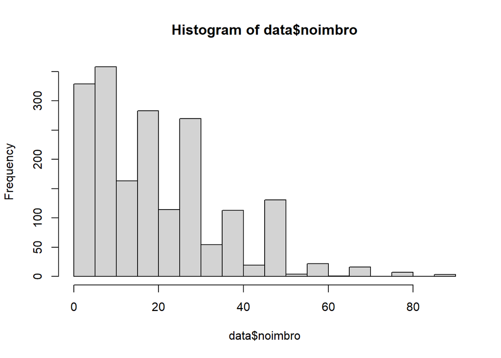

```r
hist(data$noimbro, breaks = 20)
```

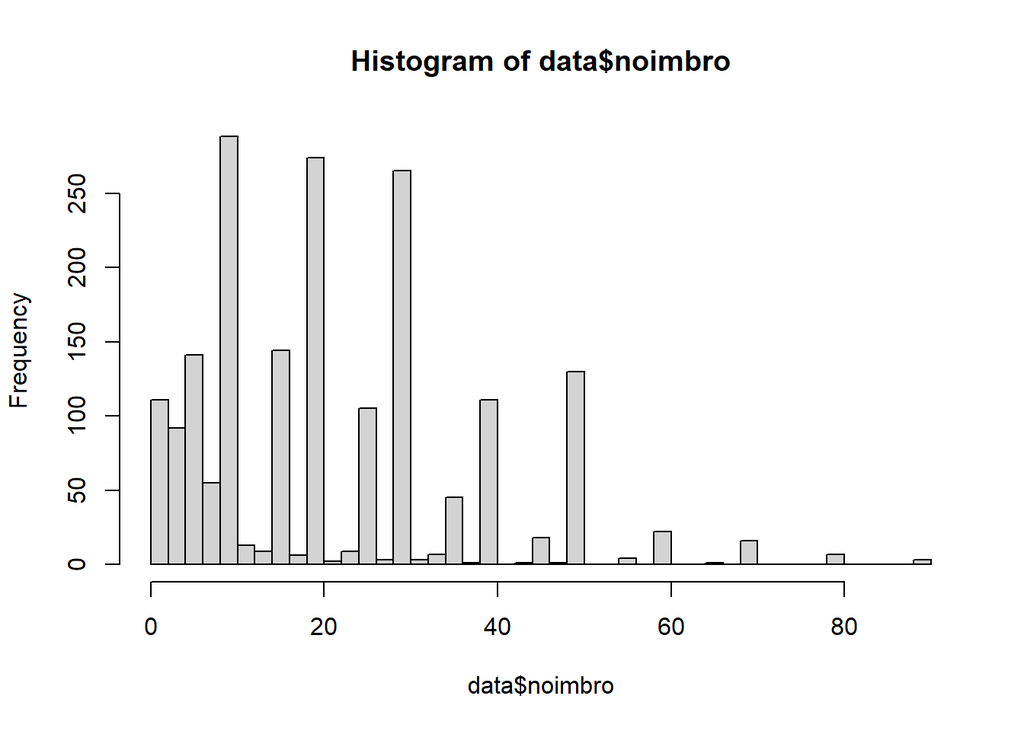

```r
hist(data$noimbro, breaks = 40)
```

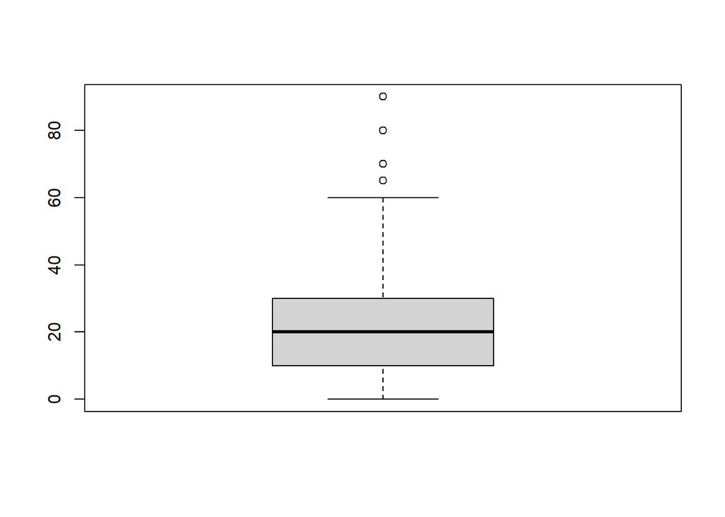

```r
boxplot(data$noimbro)
```

Kui palju on tunnuses erindeid karpdiagrammi / kvartiilhaarde põhjal?

```r
data %>%
  subset(noimbro > 60) %>%
  nrow()
```

```
## [1] 27
```

Millised väärtused kvalifitseeruvad eelneva kriteeriumi alusel erandlikeks?

```r
data %>%
  subset(noimbro > 60, select = noimbro) %>%
  freq()
```

```
## Frequencies
## noimbro
## Type: Numeric
##
##               Freq   % Valid   % Valid Cum.   % Total   % Total Cum.
## ----------- ------ --------- -------------- --------- --------------
##          65      1      3.70           3.70      3.70           3.70
##          70     16     59.26          62.96     59.26          62.96
##          80      7     25.93          88.89     25.93          88.89
##          90      3     11.11         100.00     11.11         100.00
##        <NA>      0                               0.00         100.00
##       Total     27    100.00         100.00    100.00         100.00
```

Arvutame ka z-skoorid, et nende põhjal erindeid uurida.

```r
data <- data %>%
  mutate(noimbro_z = as.numeric(scale(noimbro)))
```

Kui palju on erindeid z-skooride põhjal?

```r
freq(data$noimbro_z)
```

```
## Frequencies
## data$noimbro_z
## Type: Numeric
##
##                             Freq   % Valid   % Valid Cum.   % Total   % Total Cum.
## ------------------------- ------ --------- -------------- --------- --------------
##         -1.36764524806237      6     0.318          0.318     0.293          0.293
##         -1.30430316272025     51     2.703          3.021     2.487          2.779
##         -1.24096107737814     54     2.862          5.882     2.633          5.412
##         -1.17761899203603     64     3.392          9.274     3.120          8.532
##         -1.11427690669392     28     1.484         10.758     1.365          9.898
##          -1.0509348213518    126     6.677         17.435     6.143         16.041
##        -0.987592736009692     15     0.795         18.230     0.731         16.772
##         -0.92425065066758     27     1.431         19.661     1.316         18.089
##        -0.860908565325467     28     1.484         21.145     1.365         19.454
##        -0.797566479983355      3     0.159         21.304     0.146         19.600
##        -0.734224394641242    285    15.103         36.407    13.896         33.496
##        -0.607540223957018     13     0.689         37.096     0.634         34.130
##        -0.544198138614905      4     0.212         37.308     0.195         34.325
##        -0.480856053272793      5     0.265         37.573     0.244         34.569
##         -0.41751396793068    141     7.472         45.045     6.875         41.443
##        -0.354171882588568      3     0.159         45.204     0.146         41.589
##        -0.290829797246456      2     0.106         45.310     0.098         41.687
##        -0.227487711904343      4     0.212         45.522     0.195         41.882
##        -0.164145626562231      1     0.053         45.575     0.049         41.931
##        -0.100803541220118    273    14.467         60.042    13.311         55.241
##       -0.0374614558780061      1     0.053         60.095     0.049         55.290
##        0.0258806294641063      1     0.053         60.148     0.049         55.339
##        0.0892227148062187      7     0.371         60.519     0.341         55.680
##         0.152564800148331      2     0.106         60.625     0.098         55.778
##         0.215906885490444    103     5.458         66.084     5.022         60.800
##         0.279248970832556      2     0.106         66.190     0.098         60.897
##         0.342591056174668      1     0.053         66.243     0.049         60.946
##         0.405933141516781      2     0.106         66.349     0.098         61.043
##         0.469275226858893      1     0.053         66.402     0.049         61.092
##         0.532617312201005    264    13.990         80.392    12.872         73.964
##          0.65930148288523      3     0.159         80.551     0.146         74.110
##         0.722643568227343      7     0.371         80.922     0.341         74.451
##         0.849327738911568     44     2.332         83.254     2.145         76.597
##          0.91266982425368      1     0.053         83.307     0.049         76.646
##         0.976011909595792      1     0.053         83.360     0.049         76.694
##          1.10269608028002      2     0.106         83.466     0.098         76.792
##          1.16603816562213    109     5.776         89.242     5.314         82.106
##          1.41940650699058      1     0.053         89.295     0.049         82.155
##          1.48274859233269     18     0.954         90.249     0.878         83.033
##          1.60943276301692      1     0.053         90.302     0.049         83.081
##          1.73611693370114      1     0.053         90.355     0.049         83.130
##          1.79945901904325    129     6.836         97.191     6.290         89.420
##          2.11616944575382      4     0.212         97.403     0.195         89.615
##          2.43287987246438     22     1.166         98.569     1.073         90.687
##          2.74959029917494      1     0.053         98.622     0.049         90.736
##           3.0663007258855     16     0.848         99.470     0.780         91.516
##          3.69972157930663      7     0.371         99.841     0.341         91.858
##          4.33314243272775      3     0.159        100.000     0.146         92.004
##                      <NA>    164                              7.996        100.000
##                     Total   2051   100.000        100.000   100.000        100.000
```

Näeme siit erindite jaotust, aga mitte eriti ülevaatlikult. Vaatame, kui palju on erindeid erinevate lävendite korral.

```r
data %>%
  subset(noimbro_z > 2.5, select = noimbro) %>%
  freq()
```

```
## Frequencies
## noimbro
## Type: Numeric
##
##               Freq   % Valid   % Valid Cum.   % Total   % Total Cum.
## ----------- ------ --------- -------------- --------- --------------
##          65      1      3.70           3.70      3.70           3.70
##          70     16     59.26          62.96     59.26          62.96
##          80      7     25.93          88.89     25.93          88.89
##          90      3     11.11         100.00     11.11         100.00
##        <NA>      0                               0.00         100.00
##       Total     27    100.00         100.00    100.00         100.00
```

```r
data %>%
  subset(noimbro_z > 3, select = noimbro) %>%
  freq()
```

```
## Frequencies
## noimbro
## Type: Numeric
##
##               Freq   % Valid   % Valid Cum.   % Total   % Total Cum.
## ----------- ------ --------- -------------- --------- --------------
##          70     16     61.54          61.54     61.54          61.54
##          80      7     26.92          88.46     26.92          88.46
##          90      3     11.54         100.00     11.54         100.00
##        <NA>      0                               0.00         100.00
##       Total     26    100.00         100.00    100.00         100.00
```

```r
data %>%
  subset(noimbro_z > 3.5, select = noimbro) %>%
  freq()
```

```
## Frequencies
## noimbro
## Type: Numeric
##
##               Freq   % Valid   % Valid Cum.   % Total   % Total Cum.
## ----------- ------ --------- -------------- --------- --------------
##          80      7     70.00          70.00     70.00          70.00
##          90      3     30.00         100.00     30.00         100.00
##        <NA>      0                               0.00         100.00
##       Total     10    100.00         100.00    100.00         100.00
```

Harjutusülesanne: kas tunnuse noimbro poolest erandlike väärtustega indiviidid erinevad millegi poolest tavaväärtustega indiviididest? Kas mõne indiviidi puhul torkab midagi eripärast silma, mis aitaks mõista, mis võib erandliku väärtuse põhjuseks olla?

## Mitmemõõtmelised erindid

Uurime, kas väljaspool Eestit sündinud inimeste tajutud osakaalu ja haridustee pikkuse väärtuste kombinatsioon võiks mõnede indiviidide puhul kvalifitseeruda erindina. Eeldame, et kõrgelt haritud vastajad võiksid osata immigratsiooni puudutavaid näitajaid adekvaatselt hinnata - kui ilmneb selle eeldusega tugevalt vastuolus olevaid väärtuste kombinatsioone, võiks neid käsitleda erandlikena.

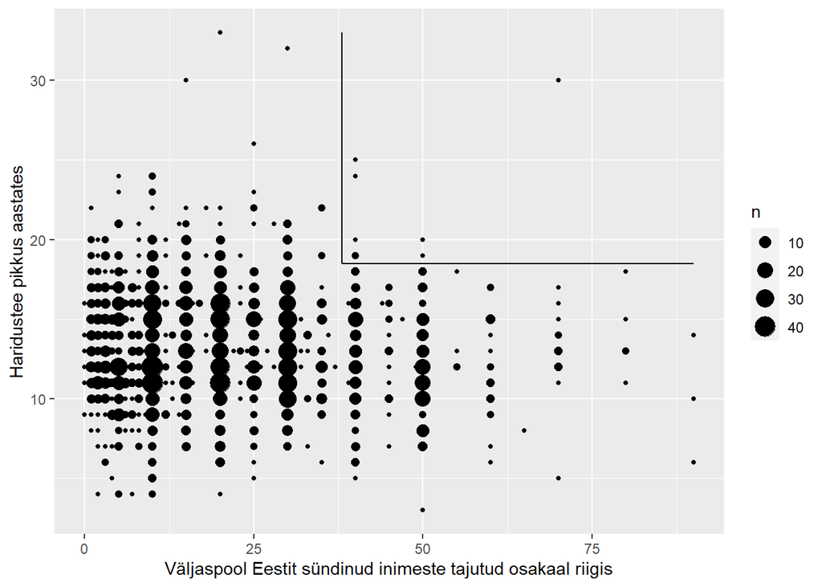

```r
ggplot(data, aes(x = noimbro, y = eduyrs)) +
  geom_count() +
  geom_segment(x = 38, y = 18.5, xend = 38, yend = 33) +
  geom_segment(x = 38, y = 18.5, xend = 90, yend = 18.5) +
  xlab("Väljaspool Eestit sündinud inimeste tajutud osakaal riigis") +
  ylab("Haridustee pikkus aastates")
```